# MIDTERM : Analytics Technology

In this assignment you are going to have several tasks:

1. Import several CSV files:
   - Physicians
   - Scripts (files 1 – 10)
   - Zip Codes
2. Create provider summary and org summary tables
3. There are 10 analysis questions each requiring a TABLE and at least 1 CHART (Barplot) To get the results you’ll likely need to break things up into steps and perform various steps including:
   - Query to filter data
   - Merge to join data
   - N-largest / N-smallest (top N, Bottom N)
   - Concat to append datasets together
   - agg (sum, count, mean, min, max)
   - create barplots using seaborn
   - Rename columns using df.column = [“col1”,”col2”,…]
4. Devise 5 of your own analysis questions answered with tables and visualizations
5. Extra Credit

```python
# --------------------------------
import warnings
warnings.filterwarnings('ignore')
# --------------------------------

import pandas as pd
import numpy as np
import matplotlib.pyplot  as plt
import seaborn as sns

%matplotlib inline
```

## Import Data

You are provided several files you'll need to import the files and append (concat) them into a single table after you import.

```
example = pd.concat(["phys1","phys2","phys3"],axis=0)
example.head()
```

**Providers:**

https://raw.githubusercontent.com/MonkeyWrenchGang/MGTPython/main/module_5/mid-term/scnctn_physicians_1.csv https://raw.githubusercontent.com/MonkeyWrenchGang/MGTPython/main/module_5/mid-term/scnctn_physicians_2.csv https://raw.githubusercontent.com/MonkeyWrenchGang/MGTPython/main/module_5/mid-term/scnctn_physicians_3.csv

**Prescriptions:**

https://raw.githubusercontent.com/MonkeyWrenchGang/MGTPython/main/module_5/mid-term/scnctn_scripts_1.csv https://raw.githubusercontent.com/MonkeyWrenchGang/MGTPython/main/module_5/mid-term/scnctn_scripts_2.csv https://raw.githubusercontent.com/MonkeyWrenchGang/MGTPython/main/module_5/mid-term/scnctn_scripts_3.csv https://raw.githubusercontent.com/MonkeyWrenchGang/MGTPython/main/module_5/mid-term/scnctn_scripts_4.csv https://raw.githubusercontent.com/MonkeyWrenchGang/MGTPython/main/module_5/mid-term/scnctn_scripts_5.csv https://raw.githubusercontent.com/MonkeyWrenchGang/MGTPython/main/module_5/mid-term/scnctn_scripts_6.csv https://raw.githubusercontent.com/MonkeyWrenchGang/MGTPython/main/module_5/mid-term/scnctn_scripts_7.csv https://raw.githubusercontent.com/MonkeyWrenchGang/MGTPython/main/module_5/mid-term/scnctn_scripts_8.csv https://raw.githubusercontent.com/MonkeyWrenchGang/MGTPython/main/module_5/mid-term/scnctn_scripts_9.csv https://raw.githubusercontent.com/MonkeyWrenchGang/MGTPython/main/module_5/mid-term/scnctn_scripts_10.csv

**Zips:** "https://raw.githubusercontent.com/MonkeyWrenchGang/MGTPython/main/module_5/mid-term/zipcode_usa.csv"

NOTE: zips is delimited by `;`

```
zips = pd.read_csv("https://raw.githubusercontent.com/MonkeyWrenchGang/MGTPython/main/module_5/mid-term/zipcode_usa.csv",sep=";")
zips.head()
```

My advice is to clean up the column names using:

```
zips.columns = ( zips.columns
    .str.strip()
    .str.lower()
    .str.replace(' ', '_')
    .str.replace('-', '_')
    .str.replace('(', '')
    .str.replace(')', '')
    .str.replace('?', '')
    .str.replace('\'', '') # notice the backslash \ this is an escape character
)
print(zips.columns)
zips.head()
```

```python
phys1 = pd.read_csv("https://raw.githubusercontent.com/MonkeyWrenchGang/MGTPython/main/module_5/mid-term/scnctn_physicians_1.csv")
phys2 = pd.read_csv("https://raw.githubusercontent.com/MonkeyWrenchGang/MGTPython/main/module_5/mid-term/scnctn_physicians_2.csv")
phys3 = pd.read_csv("https://raw.githubusercontent.com/MonkeyWrenchGang/MGTPython/main/module_5/mid-term/scnctn_physicians_3.csv")
physicians = pd.concat([phys1, phys2, phys3])
physicians.columns = physicians.columns.str.lower()
```

```python
script1 = pd.read_csv('https://raw.githubusercontent.com/MonkeyWrenchGang/MGTPython/main/module_5/mid-term/scnctn_scripts_1.csv')
script2 = pd.read_csv('https://raw.githubusercontent.com/MonkeyWrenchGang/MGTPython/main/module_5/mid-term/scnctn_scripts_2.csv')
script3 = pd.read_csv('https://raw.githubusercontent.com/MonkeyWrenchGang/MGTPython/main/module_5/mid-term/scnctn_scripts_3.csv')
script4 = pd.read_csv('https://raw.githubusercontent.com/MonkeyWrenchGang/MGTPython/main/module_5/mid-term/scnctn_scripts_4.csv')
script5 = pd.read_csv('https://raw.githubusercontent.com/MonkeyWrenchGang/MGTPython/main/module_5/mid-term/scnctn_scripts_5.csv')
script6 = pd.read_csv('https://raw.githubusercontent.com/MonkeyWrenchGang/MGTPython/main/module_5/mid-term/scnctn_scripts_6.csv')
script7 = pd.read_csv('https://raw.githubusercontent.com/MonkeyWrenchGang/MGTPython/main/module_5/mid-term/scnctn_scripts_7.csv')
script8 = pd.read_csv('https://raw.githubusercontent.com/MonkeyWrenchGang/MGTPython/main/module_5/mid-term/scnctn_scripts_8.csv')
script9 = pd.read_csv('https://raw.githubusercontent.com/MonkeyWrenchGang/MGTPython/main/module_5/mid-term/scnctn_scripts_9.csv')
script10 = pd.read_csv('https://raw.githubusercontent.com/MonkeyWrenchGang/MGTPython/main/module_5/mid-term/scnctn_scripts_10.csv')
```

```python
prescription = pd.concat([script1, script2, script3, script4, script5, script6, script7, script8, script9, script10 ])
prescription.columns = prescription.columns.str.lower()
```

```python
# import steps
zips = pd.read_csv("https://raw.githubusercontent.com/MonkeyWrenchGang/MGTPython/main/module_5/mid-term/zipcode_usa.csv",sep=";")
zips.head(2)
```

|  | Zip Code | Official USPS city name | Official USPS State Code | Official State Name | ZCTA | ZCTA parent | Population | Density | Primary Official County Code | Primary Official County Name | County Weights | Official County Name | Official County Code | Imprecise | Military | Timezone | Geo Point |
| --- | --- | --- | --- | --- | --- | --- | --- | --- | --- | --- | --- | --- | --- | --- | --- | --- | --- |
| 0 | 90005 | Los Angeles | CA | California | True | NaN | 39732.0 | 14151.8 | 6037 | Los Angeles | {"06037": "100"} | Los Angeles | 6037 | False | False | America/Los_Angeles | 34.05912, -118.30654 |
| 1 | 90006 | Los Angeles | CA | California | True | NaN | 59576.0 | 11981.7 | 6037 | Los Angeles | {"06037": "100"} | Los Angeles | 6037 | False | False | America/Los_Angeles | 34.04801, -118.29418 |

```python
zips.columns = ( zips.columns
    .str.strip()
    .str.lower()
    .str.replace(' ', '_')
    .str.replace('-', '_')
    .str.replace('(', '')
    .str.replace(')', '')
    .str.replace('?', '')
    .str.replace('\'', '') # notice the backslash \ this is an escape character
)
print(zips.columns)
zips.head(2)
```

```
Index(['zip_code', 'official_usps_city_name', 'official_usps_state_code',
       'official_state_name', 'zcta', 'zcta_parent', 'population', 'density',
       'primary_official_county_code', 'primary_official_county_name',
       'county_weights', 'official_county_name', 'official_county_code',
       'imprecise', 'military', 'timezone', 'geo_point'],
      dtype='object')
```

|  | zip_code | official_usps_city_name | official_usps_state_code | official_state_name | zcta | zcta_parent | population | density | primary_official_county_code | primary_official_county_name | county_weights | official_county_name | official_county_code | imprecise | military | timezone | geo_point |
| --- | --- | --- | --- | --- | --- | --- | --- | --- | --- | --- | --- | --- | --- | --- | --- | --- | --- |
| 0 | 90005 | Los Angeles | CA | California | True | NaN | 39732.0 | 14151.8 | 6037 | Los Angeles | {"06037": "100"} | Los Angeles | 6037 | False | False | America/Los_Angeles | 34.05912, -118.30654 |
| 1 | 90006 | Los Angeles | CA | California | True | NaN | 59576.0 | 11981.7 | 6037 | Los Angeles | {"06037": "100"} | Los Angeles | 6037 | False | False | America/Los_Angeles | 34.04801, -118.29418 |

## TASK 2 – STRUCTURE

### TASK 2A - Create Provider Summary

### TASK 2b - Create Org Summary

```python
physicians.columns
```

```
Index(['rndrng_npi', 'rndrng_prvdr_last_org_name', 'rndrng_prvdr_first_name',
       'rndrng_prvdr_mi', 'rndrng_prvdr_crdntls', 'rndrng_prvdr_gndr',
       'rndrng_prvdr_ent_cd', 'rndrng_prvdr_st1', 'rndrng_prvdr_st2',
       'rndrng_prvdr_city', 'rndrng_prvdr_state_abrvtn',
       'rndrng_prvdr_state_fips', 'rndrng_prvdr_zip5', 'rndrng_prvdr_ruca',
       'rndrng_prvdr_ruca_desc', 'rndrng_prvdr_cntry', 'rndrng_prvdr_type',
       'rndrng_prvdr_mdcr_prtcptg_ind', 'tot_hcpcs_cds', 'tot_benes',
       'tot_srvcs', 'tot_sbmtd_chrg', 'tot_mdcr_alowd_amt',
       'tot_mdcr_pymt_amt', 'tot_mdcr_stdzd_amt', 'drug_sprsn_ind',
       'drug_tot_hcpcs_cds', 'drug_tot_benes', 'drug_tot_srvcs',
       'drug_sbmtd_chrg', 'drug_mdcr_alowd_amt', 'drug_mdcr_pymt_amt',
       'drug_mdcr_stdzd_amt', 'med_sprsn_ind', 'med_tot_hcpcs_cds',
       'med_tot_benes', 'med_tot_srvcs', 'med_sbmtd_chrg',
       'med_mdcr_alowd_amt', 'med_mdcr_pymt_amt', 'med_mdcr_stdzd_amt',
       'bene_avg_age', 'bene_age_lt_65_cnt', 'bene_age_65_74_cnt',
       'bene_age_75_84_cnt', 'bene_age_gt_84_cnt', 'bene_feml_cnt',
       'bene_male_cnt', 'bene_race_wht_cnt', 'bene_race_black_cnt',
       'bene_race_api_cnt', 'bene_race_hspnc_cnt', 'bene_race_natind_cnt',
       'bene_race_othr_cnt', 'bene_dual_cnt', 'bene_ndual_cnt',
       'bene_cc_af_pct', 'bene_cc_alzhmr_pct', 'bene_cc_asthma_pct',
       'bene_cc_cncr_pct', 'bene_cc_chf_pct', 'bene_cc_ckd_pct',
       'bene_cc_copd_pct', 'bene_cc_dprssn_pct', 'bene_cc_dbts_pct',
       'bene_cc_hyplpdma_pct', 'bene_cc_hyprtnsn_pct', 'bene_cc_ihd_pct',
       'bene_cc_opo_pct', 'bene_cc_raoa_pct', 'bene_cc_sz_pct',
       'bene_cc_strok_pct', 'bene_avg_risk_scre'],
      dtype='object')
```

```python
physicians.columns
```

```
Index(['rndrng_npi', 'rndrng_prvdr_last_org_name', 'rndrng_prvdr_first_name',
       'rndrng_prvdr_mi', 'rndrng_prvdr_crdntls', 'rndrng_prvdr_gndr',
       'rndrng_prvdr_ent_cd', 'rndrng_prvdr_st1', 'rndrng_prvdr_st2',
       'rndrng_prvdr_city', 'rndrng_prvdr_state_abrvtn',
       'rndrng_prvdr_state_fips', 'rndrng_prvdr_zip5', 'rndrng_prvdr_ruca',
       'rndrng_prvdr_ruca_desc', 'rndrng_prvdr_cntry', 'rndrng_prvdr_type',
       'rndrng_prvdr_mdcr_prtcptg_ind', 'tot_hcpcs_cds', 'tot_benes',
       'tot_srvcs', 'tot_sbmtd_chrg', 'tot_mdcr_alowd_amt',
       'tot_mdcr_pymt_amt', 'tot_mdcr_stdzd_amt', 'drug_sprsn_ind',
       'drug_tot_hcpcs_cds', 'drug_tot_benes', 'drug_tot_srvcs',
       'drug_sbmtd_chrg', 'drug_mdcr_alowd_amt', 'drug_mdcr_pymt_amt',
       'drug_mdcr_stdzd_amt', 'med_sprsn_ind', 'med_tot_hcpcs_cds',
       'med_tot_benes', 'med_tot_srvcs', 'med_sbmtd_chrg',
       'med_mdcr_alowd_amt', 'med_mdcr_pymt_amt', 'med_mdcr_stdzd_amt',
       'bene_avg_age', 'bene_age_lt_65_cnt', 'bene_age_65_74_cnt',
       'bene_age_75_84_cnt', 'bene_age_gt_84_cnt', 'bene_feml_cnt',
       'bene_male_cnt', 'bene_race_wht_cnt', 'bene_race_black_cnt',
       'bene_race_api_cnt', 'bene_race_hspnc_cnt', 'bene_race_natind_cnt',
       'bene_race_othr_cnt', 'bene_dual_cnt', 'bene_ndual_cnt',
       'bene_cc_af_pct', 'bene_cc_alzhmr_pct', 'bene_cc_asthma_pct',
       'bene_cc_cncr_pct', 'bene_cc_chf_pct', 'bene_cc_ckd_pct',
       'bene_cc_copd_pct', 'bene_cc_dprssn_pct', 'bene_cc_dbts_pct',
       'bene_cc_hyplpdma_pct', 'bene_cc_hyprtnsn_pct', 'bene_cc_ihd_pct',
       'bene_cc_opo_pct', 'bene_cc_raoa_pct', 'bene_cc_sz_pct',
       'bene_cc_strok_pct', 'bene_avg_risk_scre'],
      dtype='object')
```

```python
#Physician Summary
phys_I = physicians[physicians['rndrng_prvdr_ent_cd'] == "I"]
physician_summary = phys_I.merge(
    zips,
    left_on = "rndrng_prvdr_zip5",
    right_on = "zip_code",
    how = "inner"
)
physician_summary.head(2)
```

|  | rndrng_npi | rndrng_prvdr_last_org_name | rndrng_prvdr_first_name | rndrng_prvdr_mi | rndrng_prvdr_crdntls | rndrng_prvdr_gndr | rndrng_prvdr_ent_cd | rndrng_prvdr_st1 | rndrng_prvdr_st2 | rndrng_prvdr_city | ... | density | primary_official_county_code | primary_official_county_name | county_weights | official_county_name | official_county_code | imprecise | military | timezone | geo_point |
| --- | --- | --- | --- | --- | --- | --- | --- | --- | --- | --- | --- | --- | --- | --- | --- | --- | --- | --- | --- | --- | --- |
| 0 | 1003000720 | Hernandez | Otniel | NaN | DNP | M | I | 3163 Gammon Ln Ste 422 | NaN | Clemmons | ... | 260.8 | 37067 | Forsyth | {"37067": "80.04", "37057": "19.96"} | Forsyth,Davidson | 37067,37057 | False | False | America/New_York | 36.0041, -80.37582 |
| 1 | 1013204148 | Merritt | Carrie | H | PA | F | I | 105 Stadium Oaks Dr | NaN | Clemmons | ... | 260.8 | 37067 | Forsyth | {"37067": "80.04", "37057": "19.96"} | Forsyth,Davidson | 37067,37057 | False | False | America/New_York | 36.0041, -80.37582 |

2 rows × 90 columns

```python
physician_summary["provider_name"] = physician_summary["rndrng_npi"].astype(str) + ": " + physician_summary["rndrng_prvdr_first_name"] + " " + physician_summary["rndrng_prvdr_last_org_name"]
physician_summary.head(2)
```

|  | rndrng_npi | rndrng_prvdr_last_org_name | rndrng_prvdr_first_name | rndrng_prvdr_mi | rndrng_prvdr_crdntls | rndrng_prvdr_gndr | rndrng_prvdr_ent_cd | rndrng_prvdr_st1 | rndrng_prvdr_st2 | rndrng_prvdr_city | ... | primary_official_county_code | primary_official_county_name | county_weights | official_county_name | official_county_code | imprecise | military | timezone | geo_point | provider_name |
| --- | --- | --- | --- | --- | --- | --- | --- | --- | --- | --- | --- | --- | --- | --- | --- | --- | --- | --- | --- | --- | --- |
| 0 | 1003000720 | Hernandez | Otniel | NaN | DNP | M | I | 3163 Gammon Ln Ste 422 | NaN | Clemmons | ... | 37067 | Forsyth | {"37067": "80.04", "37057": "19.96"} | Forsyth,Davidson | 37067,37057 | False | False | America/New_York | 36.0041, -80.37582 | 1003000720: Otniel Hernandez |
| 1 | 1013204148 | Merritt | Carrie | H | PA | F | I | 105 Stadium Oaks Dr | NaN | Clemmons | ... | 37067 | Forsyth | {"37067": "80.04", "37057": "19.96"} | Forsyth,Davidson | 37067,37057 | False | False | America/New_York | 36.0041, -80.37582 | 1013204148: Carrie Merritt |

2 rows × 91 columns

```python
#org summary
orgs = physicians[physicians['rndrng_prvdr_ent_cd'] == "O"]
org_summary = orgs.merge(
    zips,
    left_on = "rndrng_prvdr_zip5",
    right_on = "zip_code",
    how = "inner"
)
org_summary["org_name"] = org_summary["rndrng_npi"].astype(str) + ": " + org_summary["rndrng_prvdr_last_org_name"] + " - " + org_summary["official_usps_state_code"]
org_summary.shape
```

```
(4279, 91)
```

# TASK 3 - ANALYSIS

There are 10 analysis tasks, requiring you to build a table (RESnn) and at least one bar-chart. For each analysis add a Markdown Cell at the top denoting which analysis step this is. i've added an example for Analysis result 1

## RES01: “TOP 10 MEDICARE PROVIDERS BY TOT_MDCR_PYMT_AMT”

```python
phys_top10 = physician_summary.groupby('provider_name')[['tot_mdcr_pymt_amt']].sum().nlargest(10, ['tot_mdcr_pymt_amt']).reset_index()
phys_top10.columns = ['provider_name', 'tot_mdcr_pymt_amt']
print("RES01: “TOP 10 MEDICARE PROVIDERS BY TOT_MDCR_PYMT_AMT" )
phys_top10
```

```
RES01: “TOP 10 MEDICARE PROVIDERS BY TOT_MDCR_PYMT_AMT
```

|  | provider_name | tot_mdcr_pymt_amt |
| --- | --- | --- |
| 0 | 1851320691: Bradley Somer | 14030052.64 |
| 1 | 1366683823: Wanda Lowery | 11462667.60 |
| 2 | 1750541553: Shil Patel | 10526851.61 |
| 3 | 1023018728: Ross Kerns | 8945222.23 |
| 4 | 1801103643: Syed Sameer Nasir | 8347614.58 |
| 5 | 1679529473: David Portnoy | 8169092.45 |
| 6 | 1639179708: Mitchell Martin | 8148045.67 |
| 7 | 1932209855: Robert Lavey | 8060160.20 |
| 8 | 1982670147: John Doster | 7796761.71 |
| 9 | 1619947876: Daniel Ibach | 7643785.10 |

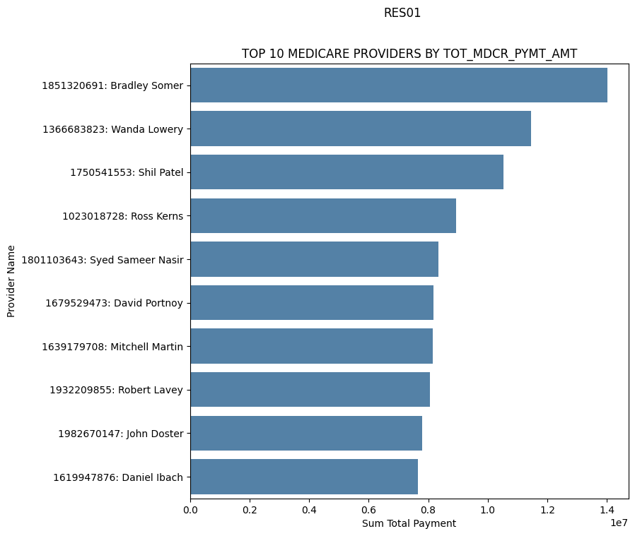

```python
plt.figure(figsize=(8, 8))
sns.barplot(data = phys_top10, x = 'tot_mdcr_pymt_amt', y = 'provider_name' , color='steelblue')
plt.suptitle('RES01')
plt.title('TOP 10 MEDICARE PROVIDERS BY TOT_MDCR_PYMT_AMT')
plt.xlabel('Sum Total Payment')
plt.ylabel('Provider Name')
#plt.xticks(phys_top10['provider_name'], phys_top10['sum_total_payment'].astype(int), rotation=45)
plt.show()
```

## RES02: TITLE “TOP 10 MEDICARE ORGANIZATIONS BY TOT_MDCR_PYMT_AMT”

```python
org_top10 = org_summary.groupby('org_name')[['tot_mdcr_pymt_amt']].sum().nlargest(10, ['tot_mdcr_pymt_amt']).reset_index()
org_top10.columns = ['org_name', 'tot_mdcr_pymt_amt']
print("RES01: “TOP 10 MEDICARE ORGANIZATIONS BY TOT_MDCR_PYMT_AMT" )
org_top10
```

```
RES01: “TOP 10 MEDICARE ORGANIZATIONS BY TOT_MDCR_PYMT_AMT
```

|  | org_name | tot_mdcr_pymt_amt |
| --- | --- | --- |
| 0 | 1538144910: Laboratory Corporation Of America ... | 2.346708e+08 |
| 1 | 1174009245: Vikor Scientific, Llc - SC | 4.219851e+07 |
| 2 | 1699782722: Aegis Sciences Corporation - TN | 3.306643e+07 |
| 3 | 1134538713: Mako Medical Laboratories, Llc - NC | 3.128753e+07 |
| 4 | 1235186800: Pathgroup Labs, Llc - TN | 2.179726e+07 |
| 5 | 1548370745: Memphis Pathology Laboratory - TN | 2.015901e+07 |
| 6 | 1750368700: Laboratory Corporation Of America ... | 1.964342e+07 |
| 7 | 1124417357: Aegis Sciences Corporation - TN | 1.693110e+07 |
| 8 | 1487212551: Quest Diagnostics Clinical Laborat... | 1.586682e+07 |
| 9 | 1508215922: Foundation Medicine, Inc. - NC | 1.564063e+07 |

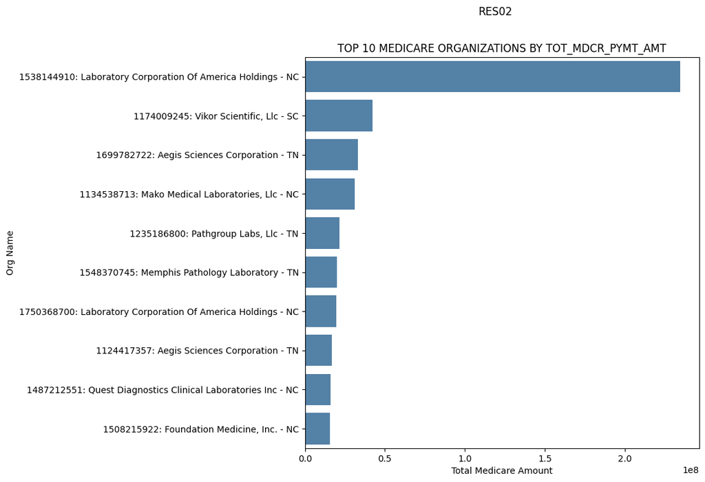

```python
plt.figure(figsize=(8, 8))
sns.barplot(data = org_top10, x = 'tot_mdcr_pymt_amt', y = 'org_name' , color='steelblue')
plt.suptitle('RES02')
plt.title('TOP 10 MEDICARE ORGANIZATIONS BY TOT_MDCR_PYMT_AMT')
plt.xlabel('Total Medicare Amount')
plt.ylabel('Org Name')
#plt.xticks(phys_top10['provider_name'], phys_top10['sum_total_payment'].astype(int), rotation=45)
plt.show()
```

## RES03: TITLE “NURSE PRACTITIONERS BY STATE”

```python
mask = physician_summary[physician_summary['rndrng_prvdr_type'] == "Nurse Practitioner"]
res3 = mask.groupby('rndrng_prvdr_state_abrvtn')['rndrng_prvdr_type'].count().reset_index()
res3.columns = ['State', 'Count']
res3 = res3.sort_values(['Count'], ascending = False)
print("RES03: NURSE PRACTITIONERS BY STATE")
res3
```

```
RES03: NURSE PRACTITIONERS BY STATE
```

|  | State | Count |
| --- | --- | --- |
| 2 | TN | 5314 |
| 0 | NC | 4997 |
| 1 | SC | 2552 |

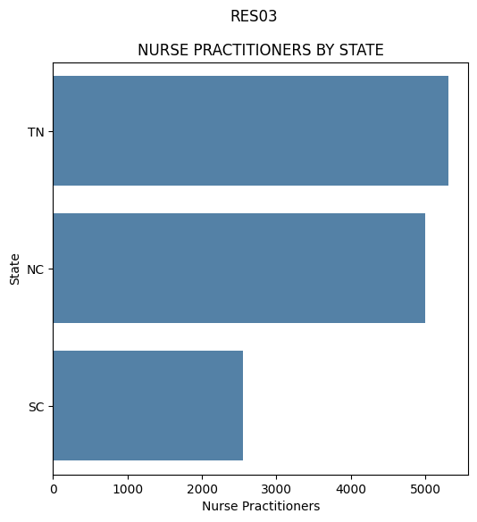

```python
plt.figure(figsize=(6, 6))
sns.barplot(data = res3, x = 'Count', y = 'State' , color='steelblue')
plt.title('NURSE PRACTITIONERS BY STATE')
plt.suptitle('RES03')
plt.xlabel('Nurse Practitioners')
plt.ylabel('State')
#plt.xticks(phys_top10['provider_name'], phys_top10['sum_total_payment'].astype(int), rotation=45)
plt.show()
```

## RES04: TITLE “ORGANIZATION TOTAL SPENDING BY STATE

```python
#ORGANIZATION TOTAL SPENDING BY STATE
res4 = org_summary.groupby('rndrng_prvdr_state_abrvtn')[['tot_mdcr_pymt_amt']].sum().reset_index()
res4.columns = ['State', 'Sum']
print('RES04: ORGANIZATION TOTAL SPENDING BY STATE')
res4.sort_values(['Sum'], ascending = False, inplace = True)
res4
```

```
RES04: ORGANIZATION TOTAL SPENDING BY STATE
```

|  | State | Sum |
| --- | --- | --- |
| 0 | NC | 6.411749e+08 |
| 2 | TN | 4.086610e+08 |
| 1 | SC | 2.890731e+08 |

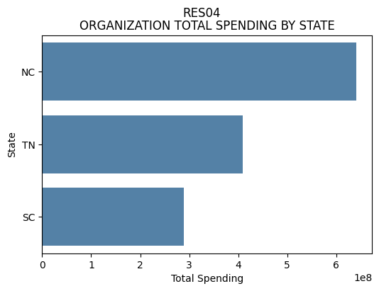

```python
plt.figure(figsize=(6, 4))
sns.barplot(data = res4, x = 'Sum', y = 'State' , color='steelblue')
plt.title('ORGANIZATION TOTAL SPENDING BY STATE')
plt.suptitle('RES04')
plt.xlabel('Total Spending')
plt.ylabel('State')
#plt.xticks(phys_top10['provider_name'], phys_top10['sum_total_payment'].astype(int), rotation=45)
plt.show()
```

## RES05: TITLE “TOP 5 ORG SPENDING BY STATE AND SPECIALTY”

```python
res05 = (org_summary.groupby(["rndrng_prvdr_state_abrvtn","rndrng_prvdr_type"])
.agg({"tot_mdcr_pymt_amt":["sum"]}) .reset_index())
res05.head(5)
```

|  | rndrng_prvdr_state_abrvtn | rndrng_prvdr_type | tot_mdcr_pymt_amt sum |
| --- | --- | --- | --- |
| 0 | NC | All Other Suppliers | 2.382725e+06 |
| 1 | NC | Ambulance Service Provider | 1.445288e+08 |
| 2 | NC | Ambulatory Surgical Center | 7.816452e+07 |
| 3 | NC | Centralized Flu | 6.572196e+06 |
| 4 | NC | Clinic or Group Practice | 1.826821e+04 |

```python
res05.columns = ['state', 'provider_type', 'sum']
#sort by state then by sum
res05 = res05.sort_values(by = ['state', 'sum'], ascending = False).groupby(['state']).head(5)
print("RES05: TOP 5 ORG SPENDING BY STATE AND SPECIALTY")
res05 = res05.sort_values('sum', ascending = False)
res05
```

```
RES05: TOP 5 ORG SPENDING BY STATE AND SPECIALTY
```

|  | state | provider_type | sum |
| --- | --- | --- | --- |
| 5 | NC | Clinical Laboratory | 3.572441e+08 |
| 1 | NC | Ambulance Service Provider | 1.445288e+08 |
| 30 | TN | Clinical Laboratory | 1.287518e+08 |
| 26 | TN | Ambulance Service Provider | 1.287374e+08 |
| 14 | SC | Ambulance Service Provider | 1.093598e+08 |
| 27 | TN | Ambulatory Surgical Center | 1.084014e+08 |
| 15 | SC | Ambulatory Surgical Center | 7.856921e+07 |
| 2 | NC | Ambulatory Surgical Center | 7.816452e+07 |
| 18 | SC | Clinical Laboratory | 7.181143e+07 |
| 8 | NC | Mass Immunizer Roster Biller | 1.600421e+07 |
| 10 | NC | Pharmacy | 1.343819e+07 |
| 32 | TN | Mass Immunizer Roster Biller | 1.084933e+07 |
| 21 | SC | Mass Immunizer Roster Biller | 1.038471e+07 |
| 19 | SC | Independent Diagnostic Testing Facility (IDTF) | 9.208320e+06 |
| 28 | TN | Centralized Flu | 7.241423e+06 |

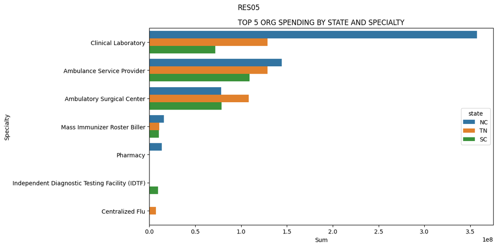

```python
plt.figure(figsize=(12, 6))
sns.barplot(data = res05, x = 'sum', y = 'provider_type', hue = 'state')
plt.title('TOP 5 ORG SPENDING BY STATE AND SPECIALTY')
plt.suptitle('RES05')
plt.tight_layout()
plt.xlabel('Sum')
plt.ylabel('Specialty')
plt.show()
```

## RES06: TITLE “TOP 5 PROVIDERs by SPENDING SPECIALTY”

```python
#“TOP 5 PROVIDER SPENDING SPECIALTY”
group = physician_summary.groupby('rndrng_prvdr_type')[['tot_mdcr_pymt_amt']].sum().reset_index()
group.columns = ['Provider Type', 'Sum Medicare Payment Amount']
res6 = group.nlargest(5, 'Sum Medicare Payment Amount')
print('RES06: TOP 5 PROVIDERS BY SPENDING SPECIALTY')
res6
```

```
RES06: TOP 5 PROVIDERS BY SPENDING SPECIALTY
```

|  | Provider Type | Sum Medicare Payment Amount |
| --- | --- | --- |
| 53 | Ophthalmology | 5.050825e+08 |
| 35 | Internal Medicine | 4.851399e+08 |
| 30 | Hematology-Oncology | 4.503906e+08 |
| 50 | Nurse Practitioner | 4.433272e+08 |
| 21 | Family Practice | 3.812270e+08 |

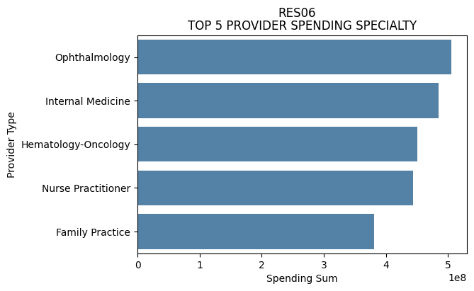

```python
plt.figure(figsize=(6, 4))
sns.barplot(data = res6, x = 'Sum Medicare Payment Amount', y = 'Provider Type' , color='steelblue')
plt.title('TOP 5 PROVIDER SPENDING SPECIALTY')
plt.suptitle('RES06')
plt.xlabel('Spending Sum')
plt.ylabel('Provider Type')
#plt.xticks(phys_top10['provider_name'], phys_top10['sum_total_payment'].astype(int), rotation=45)
plt.show()
```

## RES07: TITLE “TOP 10 GENERIC OPIATES BY TOTAL DAY SUPPLY”

```python
prescription.columns
```

```
Index(['...1', 'prscrbr_npi', 'brnd_name', 'gnrc_name', 'tot_clms',
       'tot_30day_fills', 'tot_day_suply', 'tot_drug_cst', 'tot_benes',
       'is_opiate'],
      dtype='object')
```

```python
#TOP 10 GENERIC OPIATES BY TOTAL DAY SUPPLY
opiate = prescription[prescription['is_opiate']=="Yes"]
grouped = opiate.groupby('gnrc_name')[['tot_day_suply']].sum().reset_index()

grouped.columns = ['Name', 'Sum']
print('RES07: TOP 10 GENERIC OPIATES BY TOTAL DAY SUPPLY')
res7 = grouped.nlargest(10, 'Sum')
res7
```

```
RES07: TOP 10 GENERIC OPIATES BY TOTAL DAY SUPPLY
```

|  | Name | Sum |
| --- | --- | --- |
| 10 | Hydrocodone/Acetaminophen | 43131678 |
| 20 | Oxycodone Hcl/Acetaminophen | 25397036 |
| 24 | Tramadol Hcl | 24085196 |
| 19 | Oxycodone Hcl | 19525172 |
| 16 | Morphine Sulfate | 7015124 |
| 7 | Fentanyl | 2607143 |
| 15 | Methadone Hcl | 1330175 |
| 0 | Acetaminophen With Codeine | 1208236 |
| 12 | Hydromorphone Hcl | 1091654 |
| 2 | Buprenorphine Hcl | 1078222 |

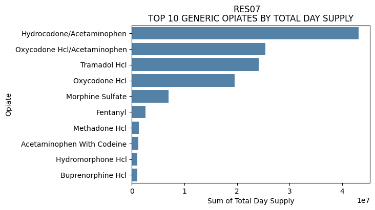

```python
plt.figure(figsize=(6, 4))
sns.barplot(data = res7, x = 'Sum', y = 'Name' , color='steelblue')
plt.title('TOP 10 GENERIC OPIATES BY TOTAL DAY SUPPLY')
plt.suptitle('RES07')
plt.xlabel('Sum of Total Day Supply')
plt.ylabel('Opiate')

plt.show()
```

## RES08: TITLE “TOP 10 MOST EXPENSIVE DRUGS”

```python
#“TOP 10 MOST EXPENSIVE DRUGS”
prescription['claim_cost'] = prescription['tot_drug_cst']/prescription['tot_clms']
group = prescription.groupby('brnd_name')['claim_cost'].mean().reset_index()
group.columns = ['Brand', 'Mean']
print('RES08: TOP 10 MOST EXPENSIVE DRUGS')
res8 = group.nlargest(10,'Mean')
res8
```

```
RES08: TOP 10 MOST EXPENSIVE DRUGS
```

|  | Brand | Mean |
| --- | --- | --- |
| 1302 | Myalept | 165046.884167 |
| 1841 | Strensiq | 112137.004791 |
| 224 | Berinert | 107622.892727 |
| 1690 | Ravicti | 95992.305556 |
| 766 | Firazyr | 75005.836171 |
| 1182 | Lumizyme | 73466.830372 |
| 361 | Chenodal | 65809.590000 |
| 61 | Aldurazyme | 63541.299286 |
| 184 | Ayvakit | 61090.000000 |
| 1634 | Procysbi | 57488.640638 |

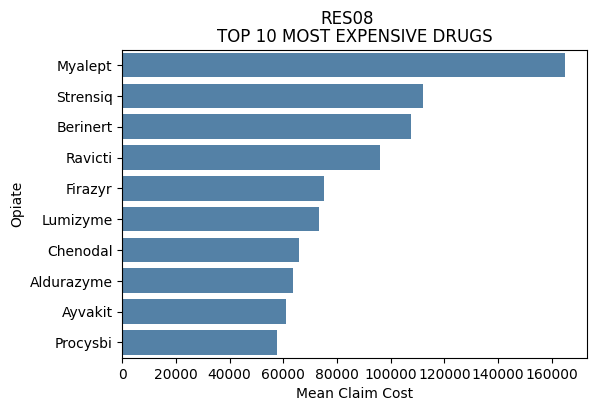

```python
plt.figure(figsize=(6, 4))
sns.barplot(data = res8, x = 'Mean', y = 'Brand' , color='steelblue')
plt.title('TOP 10 MOST EXPENSIVE DRUGS')
plt.suptitle('RES08')
plt.xlabel('Mean Claim Cost')
plt.ylabel('Opiate')

plt.show()
```

## RES09: TITLE “TOP 2 CITIES IN SC, NC, TN BY SUM OF TOTAL DAY SUPPLY FOR HYDROCODONE AND OXYCODONE”

```python
#TOP 2 CITIES IN SC, NC, TN BY SUM OF TOTAL DAY SUPPLY FOR HYDROCODONE AND OXYCODONE”
top_2 = ['Hydrocodone/Acetaminophen', 'Oxycodone Hcl/Acetaminophen']
filter = prescription['gnrc_name'].isin(top_2)
filtered = prescription[filter]

merged = filtered.merge(
    physician_summary,
    left_on = "prscrbr_npi",
    right_on = "rndrng_npi",
    how = "inner"
)

states = ['TN', 'SC', 'NC']
states_filter = merged[merged['official_usps_state_code'].isin(states)]
```

```python
#Group by ['official_usps_city_name', 'official_usps_state_code']
grouped = states_filter.groupby(['official_usps_city_name', 'official_usps_state_code']).agg({
    'tot_day_suply': ['sum', 'mean'],
    'tot_drug_cst': ['sum', 'mean']
}).reset_index()
```

```python
#Sort values by Sum of tot_day_suply largest to smallest (ascending = False)
res9 = grouped.sort_values(by = ('tot_day_suply','sum'), ascending = False)
#sorted.groupby('official_usps_state_code').head(2)
res9.columns = ["city","state","sum_day_suply","mean_day_suply","sum_cost","mean_cost"]
res9['state_city'] = res9['state'] + " - "  + res9['city']
print('RES09: TOP 2 CITIES IN SC, NC, TN BY SUM OF TOTAL DAY SUPPLY FOR HYDROCODONE AND OXYCODONE')
top2 = res9.groupby('state').head(2)
top2.sort_values(by = 'state') #sort by state
```

```
RES09: TOP 2 CITIES IN SC, NC, TN BY SUM OF TOTAL DAY SUPPLY FOR HYDROCODONE AND OXYCODONE
```

|  | city | state | sum_day_suply | mean_day_suply | sum_cost | mean_cost | state_city |
| --- | --- | --- | --- | --- | --- | --- | --- |
| 101 | Charlotte | NC | 1779301 | 1581.600889 | 2149922.08 | 1911.041849 | NC - Charlotte |
| 536 | Raleigh | NC | 972031 | 1490.845092 | 1660371.08 | 2546.581411 | NC - Raleigh |
| 617 | Spartanburg | SC | 1418811 | 4247.937126 | 1498101.82 | 4485.334790 | SC - Spartanburg |
| 214 | Florence | SC | 870433 | 2772.079618 | 1371700.68 | 4368.473503 | SC - Florence |
| 341 | Knoxville | TN | 1924268 | 1937.832830 | 2268781.57 | 2284.774995 | TN - Knoxville |
| 102 | Chattanooga | TN | 1690470 | 2493.318584 | 1910374.18 | 2817.661032 | TN - Chattanooga |

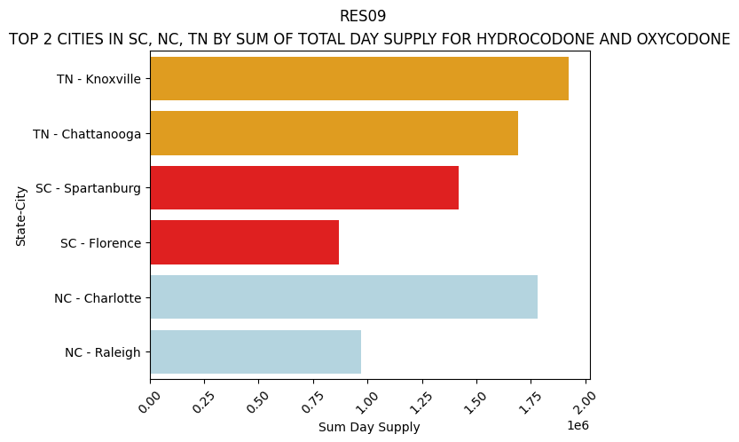

```python
#sum total day supply
palette = {'TN - Knoxville': 'orange',
           "TN - Chattanooga": "orange",
           "SC - Spartanburg": "red",
           "SC - Florence":"red",
              "NC - Charlotte" : "lightblue",
              "NC - Raleigh" : "lightblue"}
state_order = ["TN - Knoxville", "TN - Chattanooga", "SC - Spartanburg", "SC - Florence", "NC - Charlotte", "NC - Raleigh"]

sns.barplot(data = top2, y = 'state_city', x = 'sum_day_suply', palette = palette, order = state_order)
plt.title('TOP 2 CITIES IN SC, NC, TN BY SUM OF TOTAL DAY SUPPLY FOR HYDROCODONE AND OXYCODONE')
plt.suptitle('RES09')
plt.xlabel('Sum Day Supply')
# Rotate x-axis labels
plt.xticks(rotation=45)
plt.ylabel('State-City')
plt.show()
```

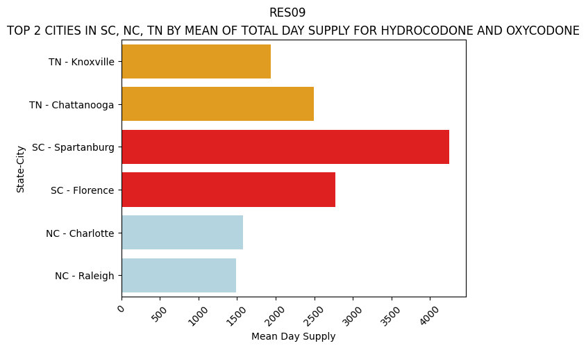

```python
sns.barplot(data = top2, y = 'state_city', x = 'mean_day_suply', palette = palette, order = state_order)
plt.title('TOP 2 CITIES IN SC, NC, TN BY MEAN OF TOTAL DAY SUPPLY FOR HYDROCODONE AND OXYCODONE')
plt.suptitle('RES09')
plt.xlabel('Mean Day Supply')
# Rotate x-axis labels
plt.xticks(rotation=45)
plt.ylabel('State-City')
plt.show()
```

This shows us that South Carolina averages the most hydrocodone & oxycodone prescriptions by day supply. It is interesting to see that these prescriptions vary so greatly among states and cities. Gathering information on what types of patients they often prescribe to would, as well as the city demographics would make for a more interesting analysis.

## RES10: TITLE "AN OPIATE A DAY"

```python
filter = zips[zips['official_usps_state_code'].isin(states)]
cities = ['Knoxville', 'Chattanooga', 'Spartanburg', 'Florence', 'Charlotte', 'Raleigh']
#filter_states = filter['official_usps_city_name'].isin('cities')
res10 = filter [filter['official_usps_city_name'].isin(cities)]
res10 = res10[['official_usps_state_code','official_usps_city_name', 'population']]
res10 = res10.groupby(['official_usps_state_code','official_usps_city_name'])['population'].sum().reset_index()
res10.columns = ['state', 'city', 'population']
print('RES10: AN OPIATE A DAY')
res10
```

```
RES10: AN OPIATE A DAY
```

|  | state | city | population |
| --- | --- | --- | --- |
| 0 | NC | Charlotte | 923655.0 |
| 1 | NC | Raleigh | 555041.0 |
| 2 | SC | Florence | 91570.0 |
| 3 | SC | Spartanburg | 112001.0 |
| 4 | TN | Charlotte | 6245.0 |
| 5 | TN | Chattanooga | 210667.0 |
| 6 | TN | Knoxville | 391360.0 |

```python
joined = res9.merge(
    res10,
    on = ['city', 'state'],
    how = "left"
)
print('RES10: AN OPIATE A DAY')
joined
```

```
RES10: AN OPIATE A DAY
```

|  | city | state | sum_day_suply | mean_day_suply | sum_cost | mean_cost | state_city | population |
| --- | --- | --- | --- | --- | --- | --- | --- | --- |
| 0 | Knoxville | TN | 1924268 | 1937.832830 | 2268781.57 | 2284.774995 | TN - Knoxville | 391360.0 |
| 1 | Charlotte | NC | 1779301 | 1581.600889 | 2149922.08 | 1911.041849 | NC - Charlotte | 923655.0 |
| 2 | Chattanooga | TN | 1690470 | 2493.318584 | 1910374.18 | 2817.661032 | TN - Chattanooga | 210667.0 |
| 3 | Nashville | TN | 1589852 | 1989.802253 | 1884533.00 | 2358.614518 | TN - Nashville | NaN |
| 4 | Spartanburg | SC | 1418811 | 4247.937126 | 1498101.82 | 4485.334790 | SC - Spartanburg | 112001.0 |
| ... | ... | ... | ... | ... | ... | ... | ... | ... |
| 721 | Gatesville | NC | 53 | 53.000000 | 79.01 | 79.010000 | NC - Gatesville | NaN |
| 722 | Ocoee | TN | 51 | 51.000000 | 56.97 | 56.970000 | TN - Ocoee | NaN |
| 723 | Prospect | TN | 48 | 48.000000 | 91.73 | 91.730000 | TN - Prospect | NaN |
| 724 | Gruetli Laager | TN | 37 | 37.000000 | 48.13 | 48.130000 | TN - Gruetli Laager | NaN |
| 725 | Kingston Springs | TN | 32 | 32.000000 | 44.30 | 44.300000 | TN - Kingston Springs | NaN |

726 rows × 8 columns

```python
joined['day supply per person'] = joined['sum_day_suply']/joined['population']
res10 = joined.nlargest(6, 'day supply per person')
print('RES10: AN OPIATE A DAY')
res10
```

```
RES10: AN OPIATE A DAY
```

|  | city | state | sum_day_suply | mean_day_suply | sum_cost | mean_cost | state_city | population | day supply per person |
| --- | --- | --- | --- | --- | --- | --- | --- | --- | --- |
| 4 | Spartanburg | SC | 1418811 | 4247.937126 | 1498101.82 | 4485.334790 | SC - Spartanburg | 112001.0 | 12.667842 |
| 9 | Florence | SC | 870433 | 2772.079618 | 1371700.68 | 4368.473503 | SC - Florence | 91570.0 | 9.505657 |
| 2 | Chattanooga | TN | 1690470 | 2493.318584 | 1910374.18 | 2817.661032 | TN - Chattanooga | 210667.0 | 8.024370 |
| 0 | Knoxville | TN | 1924268 | 1937.832830 | 2268781.57 | 2284.774995 | TN - Knoxville | 391360.0 | 4.916874 |
| 1 | Charlotte | NC | 1779301 | 1581.600889 | 2149922.08 | 1911.041849 | NC - Charlotte | 923655.0 | 1.926370 |
| 7 | Raleigh | NC | 972031 | 1490.845092 | 1660371.08 | 2546.581411 | NC - Raleigh | 555041.0 | 1.751278 |

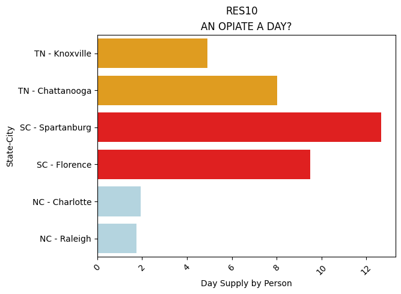

```python
sns.barplot(data = res10, y = 'state_city', x = 'day supply per person', palette = palette, order = state_order)
plt.title('AN OPIATE A DAY?')
plt.suptitle('RES10')
plt.xlabel('Day Supply by Person')
# Rotate x-axis labels
plt.xticks(rotation=45)
plt.ylabel('State-City')
plt.show()
```

This graph tells us that day supply of opiates by population is highest in South Carolina. More analysis should be done to see what factors are influencing the higher supply of opiates. Additional information for a more interesting analysis would be looking at the demographics of the locations, as well as what types of patients are recieving opiates. These may be cities with a lot of hospitals, which is causing the increase in opiates and confounding the results.

# TASK 4 YOUR ANALYSIS

RES11 - WHICH OPIATES HAD THE MOST CLAIMS

```python
#RES11
#which opiates had the most claims?

opiate_presc = prescription[prescription['is_opiate']=="Yes"]
grouped_opiate = opiate_presc.groupby('gnrc_name')[['tot_clms']].sum().sort_values(by = 'tot_clms', ascending = False).nlargest(10,'tot_clms').reset_index()
grouped_opiate.columns = ['Drug Name', 'Total Claims']
print("RES11: OPIATES WITH THE MOST CLAIMS")
grouped_opiate
```

```
RES11: OPIATES WITH THE MOST CLAIMS
```

|  | Drug Name | Total Claims |
| --- | --- | --- |
| 0 | Hydrocodone/Acetaminophen | 1971057 |
| 1 | Tramadol Hcl | 1112032 |
| 2 | Oxycodone Hcl/Acetaminophen | 1031181 |
| 3 | Oxycodone Hcl | 803742 |
| 4 | Morphine Sulfate | 247725 |
| 5 | Fentanyl | 91917 |
| 6 | Acetaminophen With Codeine | 72806 |
| 7 | Methadone Hcl | 46728 |
| 8 | Hydromorphone Hcl | 45876 |
| 9 | Buprenorphine Hcl | 43504 |

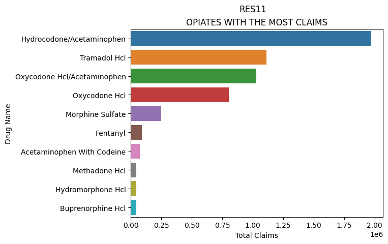

```python
sns.barplot(data = grouped_opiate, y = 'Drug Name', x = 'Total Claims')
plt.title('OPIATES WITH THE MOST CLAIMS')
plt.suptitle('RES11')
# plt.xlabel('Mean Day Supply')
# # Rotate x-axis labels
# plt.xticks(rotation=45)
# plt.ylabel('State-City')
plt.show()
```

RES12 - WHAT BENEFICIARY FACTORS CORRELATE TO MORE OPIATE PRESCRIPTIONS

```python
#RES12
#WHAT BENEFICIARY FACTORS CORRELATE TO HIGHER DAY SUPPLY OF OPIATES
phys_opiate = opiate_presc.merge(
    physician_summary,
    left_on = 'prscrbr_npi',
    right_on = 'rndrng_npi',
    how = 'inner'
)
phys_opiate.head(2)
```

|  | ...1 | prscrbr_npi | brnd_name | gnrc_name | tot_clms | tot_30day_fills | tot_day_suply | tot_drug_cst | tot_benes_x | is_opiate | ... | primary_official_county_code | primary_official_county_name | county_weights | official_county_name | official_county_code | imprecise | military | timezone | geo_point | provider_name |
| --- | --- | --- | --- | --- | --- | --- | --- | --- | --- | --- | --- | --- | --- | --- | --- | --- | --- | --- | --- | --- | --- |
| 0 | 73.0 | 1003006503 | Hydromorphone Hcl | Hydromorphone Hcl | 18 | 18.0 | 262 | 135.85 | NaN | Yes | ... | 37081 | Guilford | {"37081": "100"} | Guilford | 37081 | False | False | America/New_York | 36.07011, -79.76582 | 1003006503: Olugbemiga Jegede |
| 1 | 77.0 | 1003006503 | Oxycodone Hcl | Oxycodone Hcl | 42 | 42.0 | 594 | 606.17 | 19.0 | Yes | ... | 37081 | Guilford | {"37081": "100"} | Guilford | 37081 | False | False | America/New_York | 36.07011, -79.76582 | 1003006503: Olugbemiga Jegede |

2 rows × 102 columns

```python
bene_avg_risk_corr = phys_opiate['tot_day_suply'].corr(phys_opiate['bene_avg_risk_scre'])
age_corr = phys_opiate['tot_day_suply'].corr(phys_opiate['bene_avg_age'])
cancer_corr = phys_opiate['tot_day_suply'].corr(phys_opiate['bene_cc_cncr_pct'])
asthma_corr = phys_opiate['tot_day_suply'].corr(phys_opiate['bene_cc_asthma_pct'])
alzheimers_corr = phys_opiate['tot_day_suply'].corr(phys_opiate['bene_cc_alzhmr_pct'])
chronickidney_corr = phys_opiate['tot_day_suply'].corr(phys_opiate['bene_cc_ckd_pct'])
atrialfibrillation_corr = phys_opiate['tot_day_suply'].corr(phys_opiate['bene_cc_af_pct'])
```

```python
data = {
    'Beneficiary Factor': ['Avg Risk', 'Age', 'Cancer', 'Asthma', 'Alzheimers', 'Chronic Kidney', 'Atrial Fibrillation'],
    'Correlation': [bene_avg_risk_corr, age_corr, cancer_corr, asthma_corr,alzheimers_corr,chronickidney_corr,atrialfibrillation_corr],
}
df = pd.DataFrame(data)
print('RES12: WHAT BENEFICIARY FACTORS CORRELATE TO HIGHER DAY SUPPLY OF OPIATES')
df
```

```
RES12: WHAT BENEFICIARY FACTORS CORRELATE TO HIGHER DAY SUPPLY OF OPIATES
```

|  | Beneficiary Factor | Correlation |
| --- | --- | --- |
| 0 | Avg Risk | -0.041284 |
| 1 | Age | -0.171804 |
| 2 | Cancer | -0.117224 |
| 3 | Asthma | 0.022187 |
| 4 | Alzheimers | -0.098254 |
| 5 | Chronic Kidney | -0.069543 |
| 6 | Atrial Fibrillation | -0.152768 |

The beneficiary factors have a weak correlation to total day supply.

Age has the strongest correlation, so let's look at scatter plot for that.

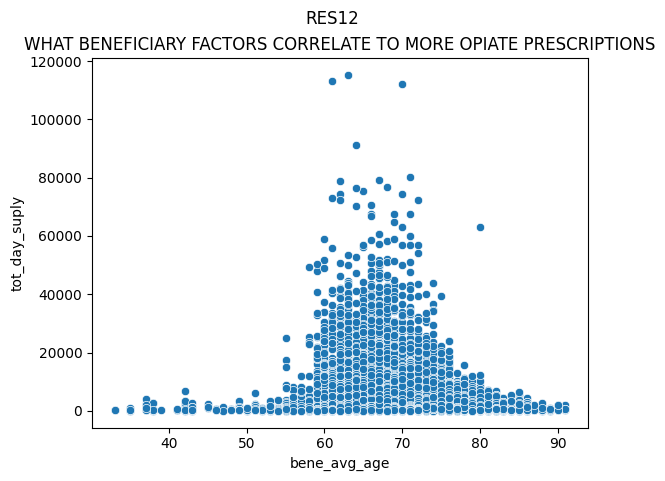

```python
sns.scatterplot(data = phys_opiate, x = 'bene_avg_age', y = 'tot_day_suply')
plt.title("WHAT BENEFICIARY FACTORS CORRELATE TO MORE OPIATE PRESCRIPTIONS")
plt.suptitle("RES12")
```

RES13 - WHICH PROVIDERS PRESCRIBE THE MOST OPIATES

```python
print("RES13: WHICH PROVIDERS PRESCRIBE THE MOST OPIATES")
top10_phys = phys_opiate.groupby('provider_name')[['tot_clms']].sum().nlargest(10, 'tot_clms').reset_index()
top10_phys
```

```
RES13: WHICH PROVIDERS PRESCRIBE THE MOST OPIATES
```

|  | provider_name | tot_clms |
| --- | --- | --- |
| 0 | 1568410223: Joseph O'quinn | 8896 |
| 1 | 1538175245: Gregory Browning | 8551 |
| 2 | 1346275260: Billy Smith | 8337 |
| 3 | 1225075088: Eric Loudermilk | 8165 |
| 4 | 1467521567: Neal Taub | 7768 |
| 5 | 1528045978: David Rogers | 7639 |
| 6 | 1376821561: Tammy Burke | 6910 |
| 7 | 1861435869: Michael Stephens | 6825 |
| 8 | 1265431035: Paul Pinson | 6699 |
| 9 | 1679681647: Scott Sauer | 6321 |

[output not shown]

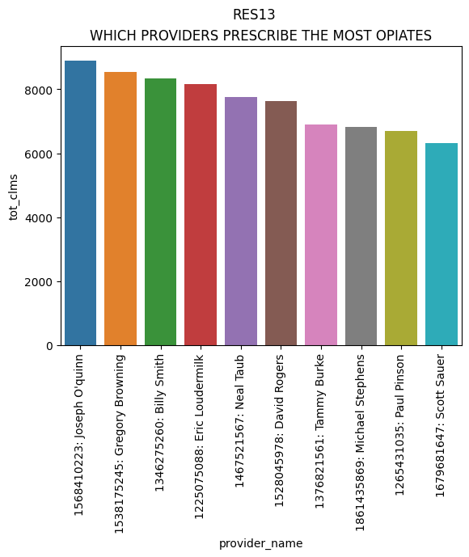

```python
sns.barplot(data = top10_phys, x = 'provider_name', y ='tot_clms')
plt.title("WHICH PROVIDERS PRESCRIBE THE MOST OPIATES")
plt.suptitle("RES13")
plt.xticks(rotation = 90)
```

```python
#RES14
clms_by_zip = phys_opiate.groupby('primary_official_county_code')['tot_clms'].sum()
top_zip = clms_by_zip.nlargest(10, keep = 'all').reset_index()
top_zip.columns = ['zip', 'total claims']
print('RES14: WHICH ZIPCODES HAVE THE MOST OPIATE PRESCRIPTIONS')
top_zip
```

```
RES14: WHICH ZIPCODES HAVE THE MOST OPIATE PRESCRIPTIONS
```

|  | zip | total claims |
| --- | --- | --- |
| 0 | 37119 | 193313 |
| 1 | 47093 | 185518 |
| 2 | 47037 | 171309 |
| 3 | 47157 | 162582 |
| 4 | 47065 | 144392 |
| 5 | 37183 | 144330 |
| 6 | 37081 | 138749 |
| 7 | 45045 | 119606 |
| 8 | 37021 | 103251 |
| 9 | 45083 | 96101 |

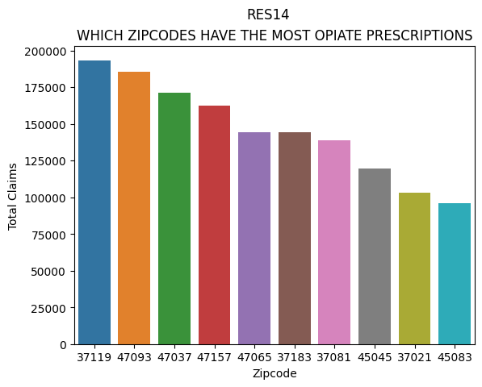

```python
top_zip_sorted = top_zip.sort_values(by='total claims', ascending=False)
sns.barplot(data = top_zip, x = 'zip', y = 'total claims', order = top_zip_sorted['zip'])
plt.title('WHICH ZIPCODES HAVE THE MOST OPIATE PRESCRIPTIONS')
plt.suptitle("RES14")
plt.xlabel('Zipcode')
plt.ylabel('Total Claims')
plt.show()
```

RES15: Do male or female physicians prescribe more opiates?

```python
print('RES15: DO MALE OR FEMALE PHYSICIANS PRESCRIBE MORE OPIATES')
m_f = phys_opiate.groupby(['rndrng_prvdr_gndr'])[['tot_clms']].mean()
m_f
```

```
RES15: DO MALE OR FEMALE PHYSICIANS PRESCRIBE MORE OPIATES
```

| rndrng_prvdr_gndr | tot_clms |
| --- | --- |
| F | 69.330151 |
| M | 75.069954 |

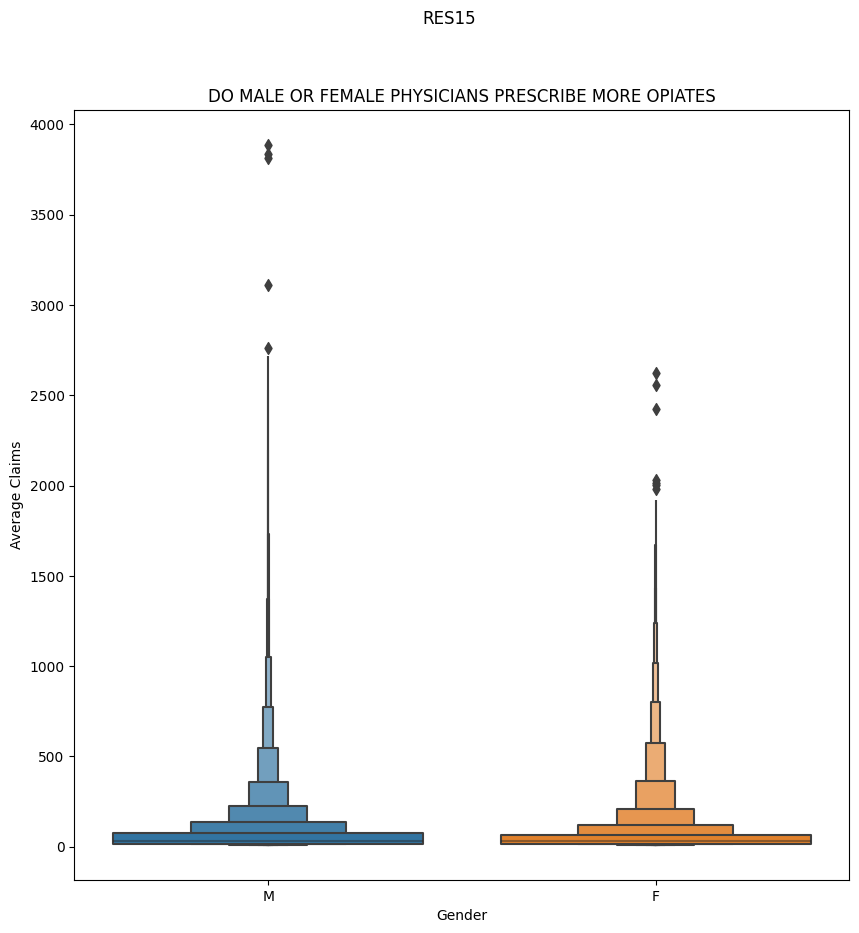

```python
plt.figure(figsize=(10, 10))
sns.boxenplot(data = phys_opiate, x ='rndrng_prvdr_gndr', y = 'tot_clms')
plt.title('DO MALE OR FEMALE PHYSICIANS PRESCRIBE MORE OPIATES')
plt.suptitle('RES15')
plt.xlabel('Gender')
plt.ylabel('Average Claims')
plt.show()
```

```python
prescription['is_opiate'].value_counts(normalize = True)
```

```
No     0.959644
Yes    0.040356
Name: is_opiate, dtype: float64
```